# weather and drive amount

Yuqing Xue

11/30/2019

# Temperature and Taxi Use

In this part, we want to see whether there is a trend between weather and yellow cab use. We use the weather data including temperature and precipitation data in 2018. For temperature, we use average temperature as the mean of maximum temperarure and miniminum temperature in each day.

Here we make an animation plot to show the daily drive amount and average daily temperature for each month.The size of the dots shows the precipitaiton for that day which help to identify whether rainy weather also increase taxi use.

Although we hypothesis that cold weather and hot weather might have more taxi use, there is no obvious difference for different daily temperature. There is a slightly increase daily taxi usage in Feburary.

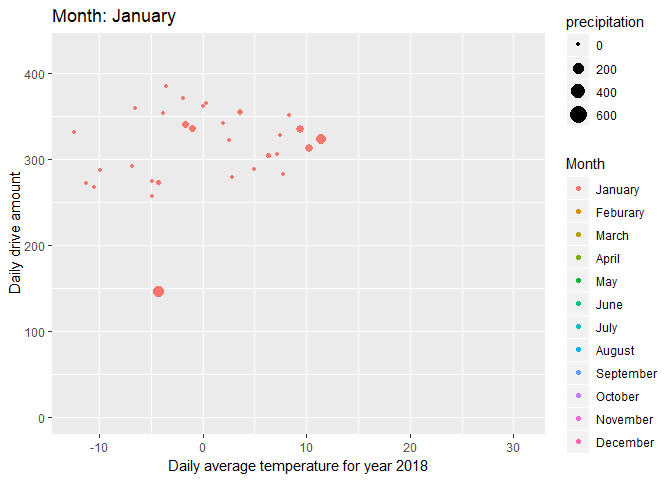

# Precipitation and Taxi Use

Still, there is no obvious difference in the taxi use.

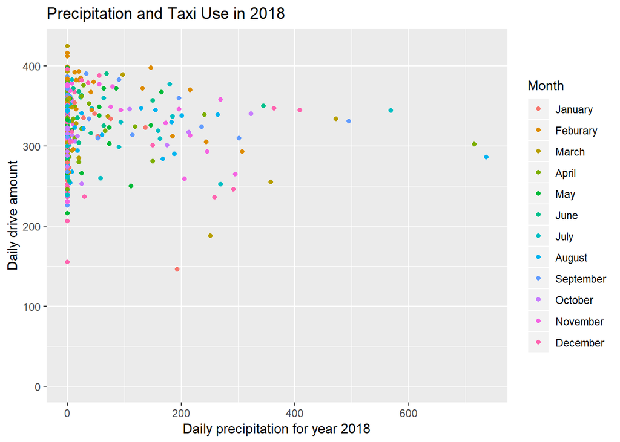